# Visualization

```r
library(tidyverse)
library(ggstats)

atus_fmt<-readRDS(here::here('Data/atus.rds'))
```

## Example data

- Data from the 2024 [American Time Use Survey](https://www.bls.gov/tus/)
- Conducted annually since 2003.
- Respondents answer questions about how much of their time is spent performing various activities (childcare, work, school, recreation etc.)
- I’ve done some reformatting and aggregation to simplify some analyses.

```r
library(tidyverse)
library(ggstats)

file<-url("https://github.com/Neilblund/SDSB340-Spring-2026/raw/refs/heads/master/Data/atus.rds")
atus_fmt<-readRDS(file)
```

## Visualization

### Bad Visuals

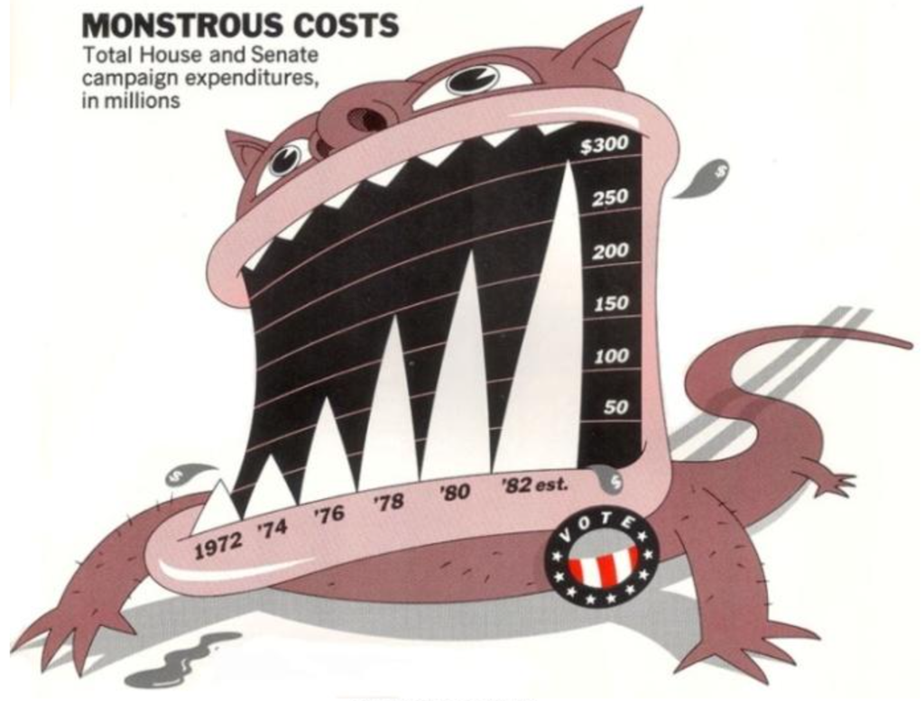

### Parts of a plot

Required components:

1. Data and mapping: We need to choose what elements we’ll be visualizing and how they map onto different parts of the plot (what goes on the x and y axis? If we’re color coding, what variables determine colors? Or shapes?)
2. Layers: the visible representations of the data. The most important being geometries (bar, point, line etc.)
3. Scales: the mapping from data units to distances, colors, etc.
4. The remaining elements can be modified, but they’re often left at default values (ggplot assumes you want carteesian coordinates unless you say otherwise, for instance)

### Dimensionality

- Data is multi-dimensional, but visuals are 2D.
- A core challenge for good visualization is elegantly handling this dimensional mismatch by:
  - simplifying data
  - color/shape/symbol encoding
  - faceting

## ggplot

- Base R already has pretty good support for data visualization, but `ggplot2` is usually easier to pick up and requires less code to do cool stuff.

### ggplot

You’ll always start with a call to ggplot

On it’s own, this just makes empty space.

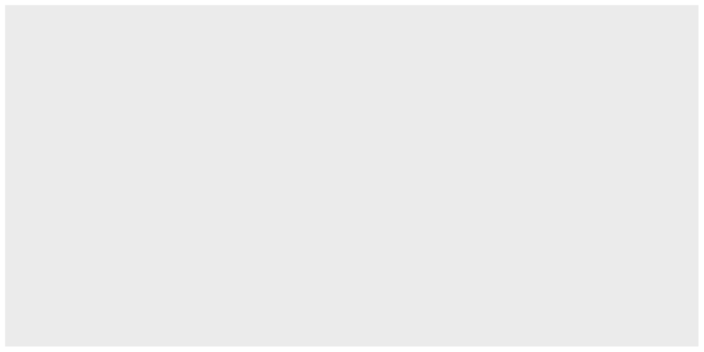

```r
ggplot()
```

We can add data and aesthetics to control what goes into the space: axes, colors, positions etc.

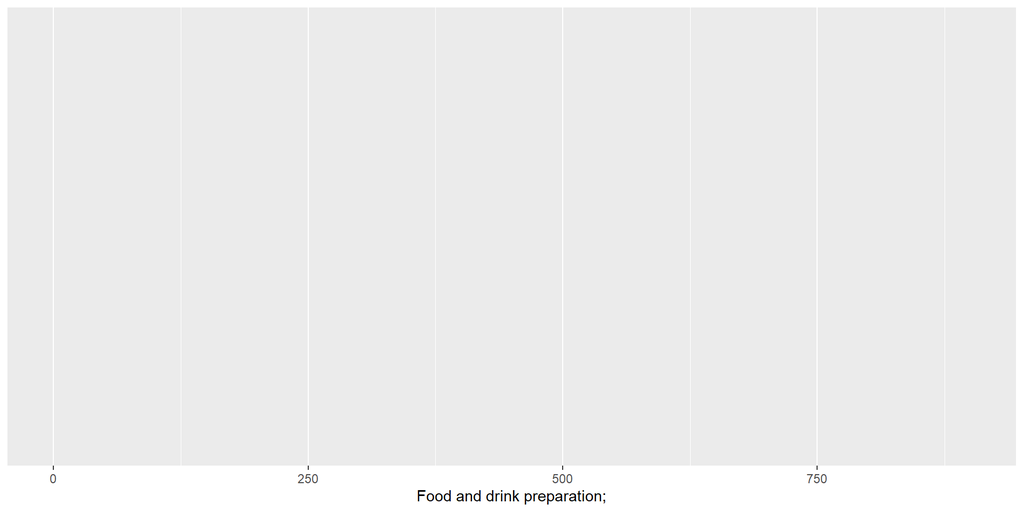

```r
ggplot(data  = atus_fmt, aes(x=t020201))
```

```r
# equivalent with pipe:
#atus_fmt|>
#  ggplot(aes(x=t020201))
```

### ggplot geometry

- You’ll use the `+` to add more layers to a ggplot object.
- Layers with the prefix `geom_` will give us different plot types: `geom_point()` (scatterplots), `geom_boxplot()` (boxplots), `geom_bar()` (barplots) etc.

### ggplot geometry

You’ll use the `+` to add one or more layers to a ggplot object. Layers with the `geom_` prefix will produce different kinds of plots:

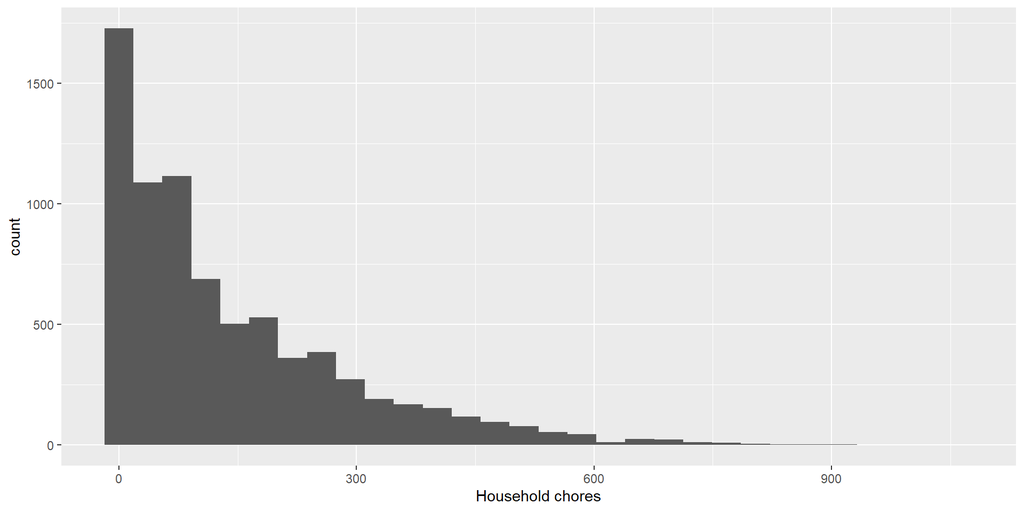

```r
ggplot(data  = atus_fmt, aes(x=chores)) +
  geom_histogram()
```

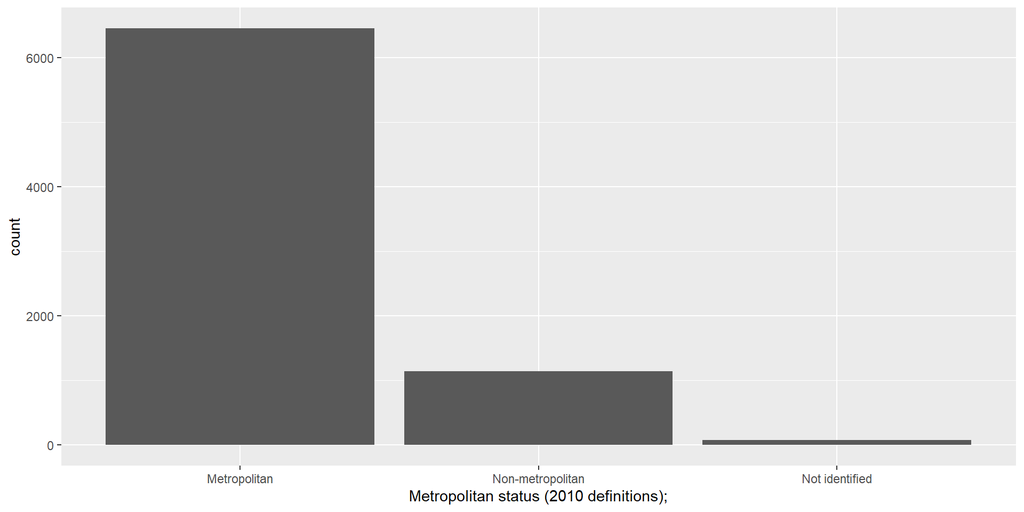

```r
ggplot(atus_fmt, aes(x=GTMETSTA)) + geom_bar()
```

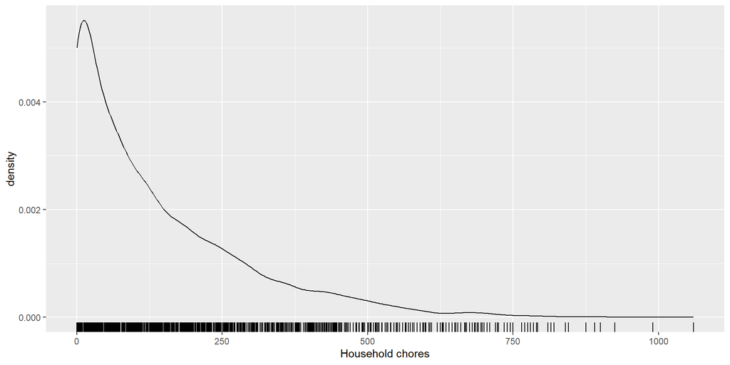

```r
ggplot(data  = atus_fmt, aes(x=chores)) +
  geom_density() +  # kernel density
  geom_rug() # rug plot
```

### ggplot scales

We can also change the x or y scaling from the default using `scale_` functions

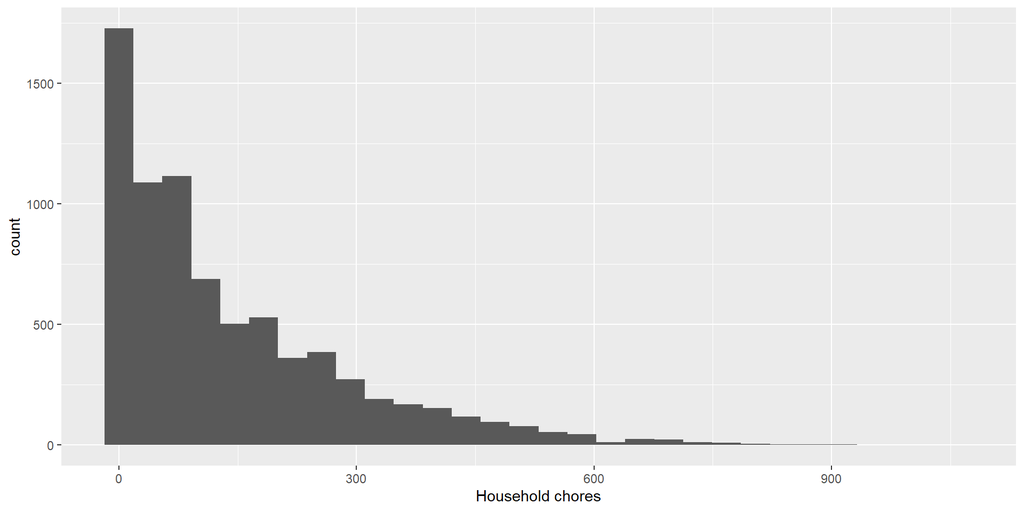

```r
ggplot(data  = atus_fmt, aes(x=chores)) +
  geom_histogram()
```

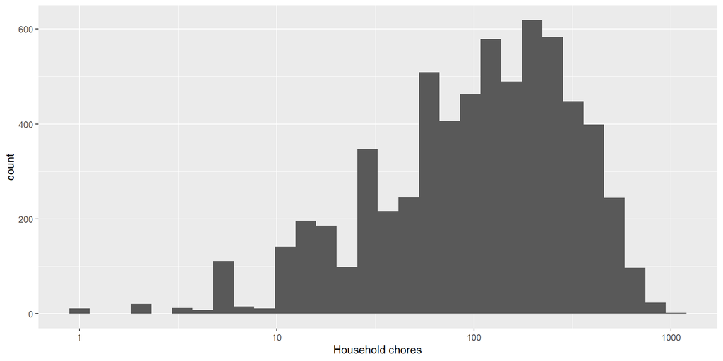

```r
ggplot(data  = atus_fmt, aes(x=chores)) +
  geom_histogram() +
  scale_x_log10() # logarithmic scale
```

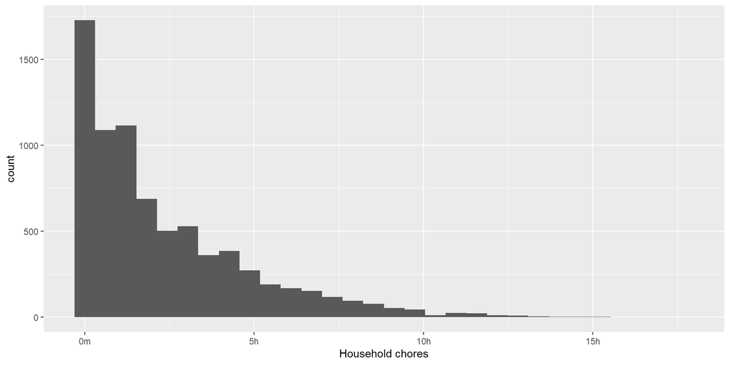

```r
label_hours_minutes <- function(x) {
  h <- floor(x / 60)
  m <- round(x %% 60)

  # Logic to create strings like "1h 30m", "45m", or "2h"
  labels <- ifelse(h > 0,
                   paste0(h, "h", ifelse(m > 0, paste0(" ", m, "m"), "")),
                   paste0(m, "m"))

  # Ensure NAs remain NAs
  labels[is.na(x)] <- NA
  return(labels)
}

ggplot(data  = atus_fmt, aes(x=chores)) +
  geom_histogram() +
  # using a custom label function to show hours and minutes
  scale_x_continuous(labels = label_hours_minutes)
```

### ggplot labels

You can use `labs` to add a title and/or modify the x and y axis labels:

```r
ggplot(data  = atus_fmt, aes(x=chores)) +
  geom_histogram() +
  labs(title = "Time spent doing household chores",
       caption = "Source: American Time Use Survey, 2024",
       x = "Time spent on chores",
       y = "Count"
  )
```

```r
ggplot(data  = atus_fmt, aes(x=chores)) +
  geom_histogram() +
  labs(title = "Time spent doing household chores",
       caption = "Source: American Time Use Survey, 2024",
       x = "Time spent on chores",
       y = "Count"
  )
```

### ggplot themes

Or modify the [theme](https://ggplot2.tidyverse.org/reference/ggtheme.html)

```r
ggplot(data  = atus_fmt, aes(x=chores)) +
  geom_histogram() +
  labs(title = "Time spent doing household chores",
       caption = "Source: American Time Use Survey, 2024",
       x = "Time spent on chores",
       y = "Count"
  )
```

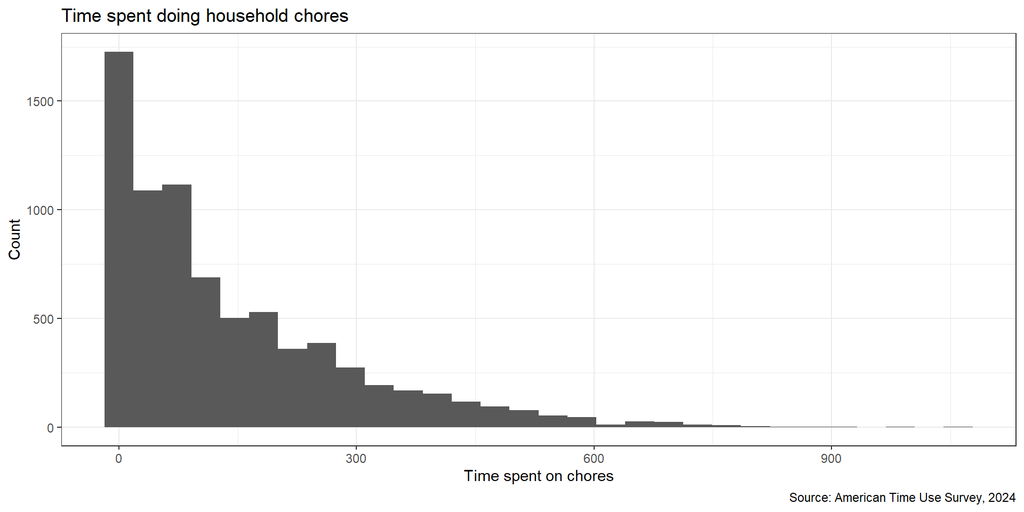

```r
ggplot(data  = atus_fmt, aes(x=chores)) +
  geom_histogram() +
  labs(title = "Time spent doing household chores",
       caption = "Source: American Time Use Survey, 2024",
       x = "Time spent on chores",
       y = "Count"
  )+
  theme_bw()
```

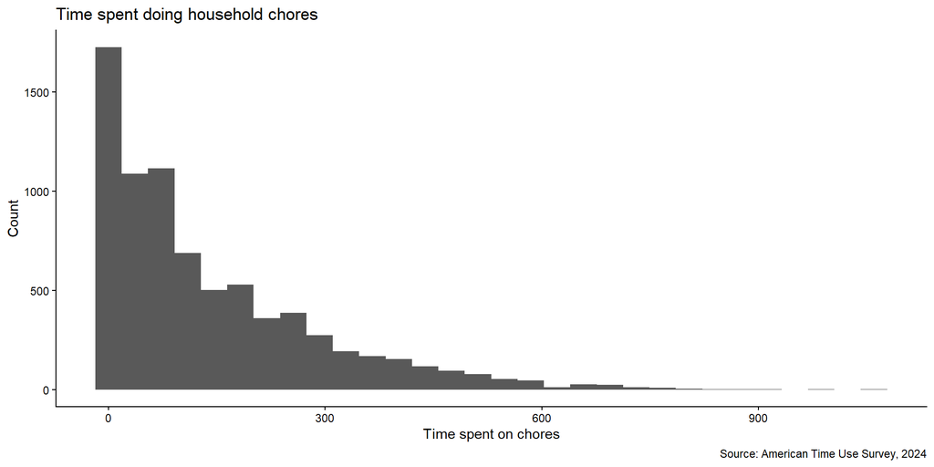

```r
ggplot(data  = atus_fmt, aes(x=chores)) +
  geom_histogram() +
  labs(title = "Time spent doing household chores",
       caption = "Source: American Time Use Survey, 2024",
       x = "Time spent on chores",
       y = "Count"
  ) +
  theme_classic()
```

## Try it out

```r
library(tidyverse)

file<-url("https://github.com/Neilblund/SDSB340-Spring-2026/raw/refs/heads/master/Data/atus.rds")
atus_fmt<-readRDS(file)
label_hours_minutes <- function(x) {
  h <- floor(x / 60)
  m <- round(x %% 60)

  # Logic to create strings like "1h 30m", "45m", or "2h"
  labels <- ifelse(h > 0,
                   paste0(h, "h", ifelse(m > 0, paste0(" ", m, "m"), "")),
                   paste0(m, "m"))

  # Ensure NAs remain NAs
  labels[is.na(x)] <- NA
  return(labels)
}
```

1. Create a histogram to show time spent on one of the other activities: `sleep`, `work`, `education`, `travel`, `religious_activities` or `sports_recreation`
2. Add x and y axis labels, a title, subtitle, and caption.
3. Pick a [theme](https://ggplot2.tidyverse.org/reference/ggtheme.html) and apply it.
4. Use the `label_hours_minutes` function to format the x-axis.
5. Assign the result to an object and use the [`ggsave`](https://ggplot2.tidyverse.org/reference/ggsave.html) function to export it to a file.

## Plotting data multiple dimensions

### Dimensions and color-coding

To capture an additional dimension, you can put another variable on the y-axis

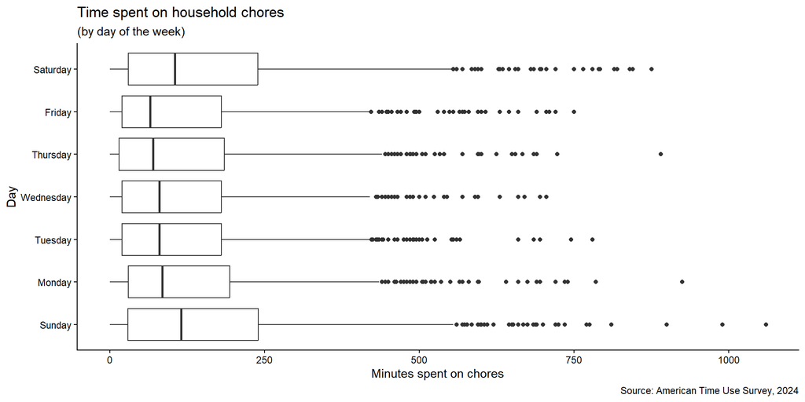

```r
ggplot(data  = atus_fmt, aes(x = chores, y = TUDIARYDAY))  +
  geom_boxplot() +
  labs(
    title = "Time spent on household chores",
    subtitle = "(by day of the week)",
    x = "Minutes spent on chores",
    y = "Day",
    caption = "Source: American Time Use Survey, 2024",
  ) +
  theme_classic()
```

### Dimensions and color-coding

For additional dimensions beyond 2, you can use `color` or `fill`, `shape`, or `size` in the aesthetics to distinguish groups.

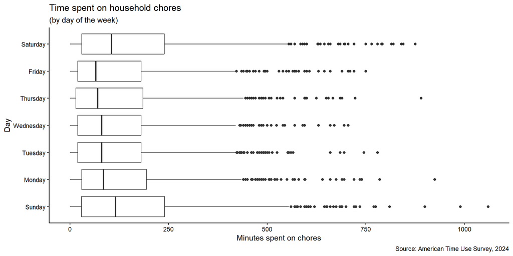

```r
ggplot(data  = atus_fmt, aes(x = chores, y = TUDIARYDAY))  +
  geom_boxplot() +
  labs(
    title = "Time spent on household chores",
    subtitle = "(by day of the week)",
    x = "Minutes spent on chores",
    y = "Day",
    caption = "Source: American Time Use Survey, 2024",
  ) +
  theme_classic()
```

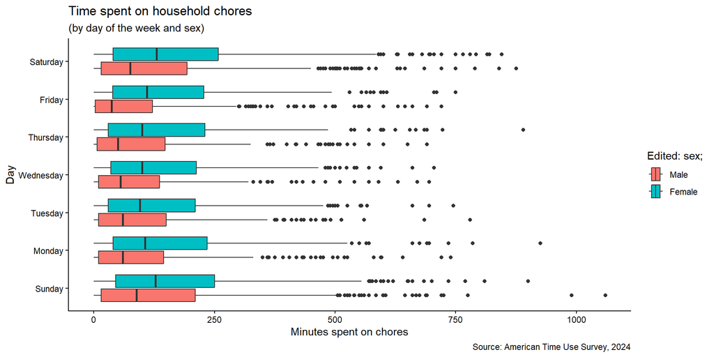

```r
ggplot(data  = atus_fmt, aes(x = chores,
                             y = TUDIARYDAY,
                             fill = TESEX,

                             ))  +
  geom_boxplot() +
  labs(
    title = "Time spent on household chores",
    subtitle = "(by day of the week and sex)",
    x = "Minutes spent on chores",
    y = "Day",
    caption = "Source: American Time Use Survey, 2024",
  )  +
  theme_classic()
```

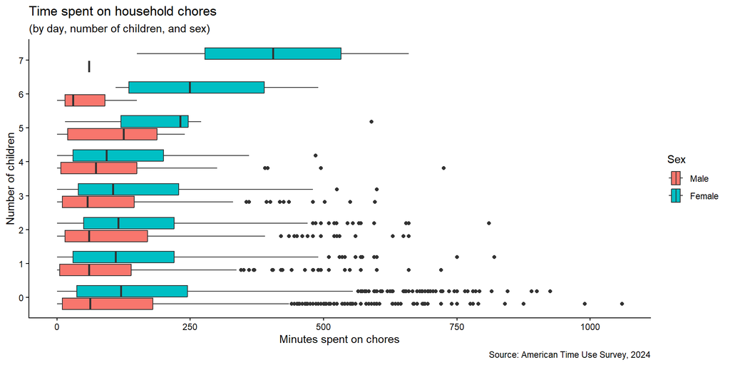

```r
ggplot(data  = atus_fmt, aes(y= factor(TRCHILDNUM), fill=TESEX, x = chores))  +
  geom_boxplot() +
  labs(
    title = "Time spent on household chores",
    subtitle = "(by day, number of children, and sex)",
    x = "Minutes spent on chores",
    y = "Number of children",
    fill = "Sex",
    caption = "Source: American Time Use Survey, 2024",
  ) +
  theme_classic()
```

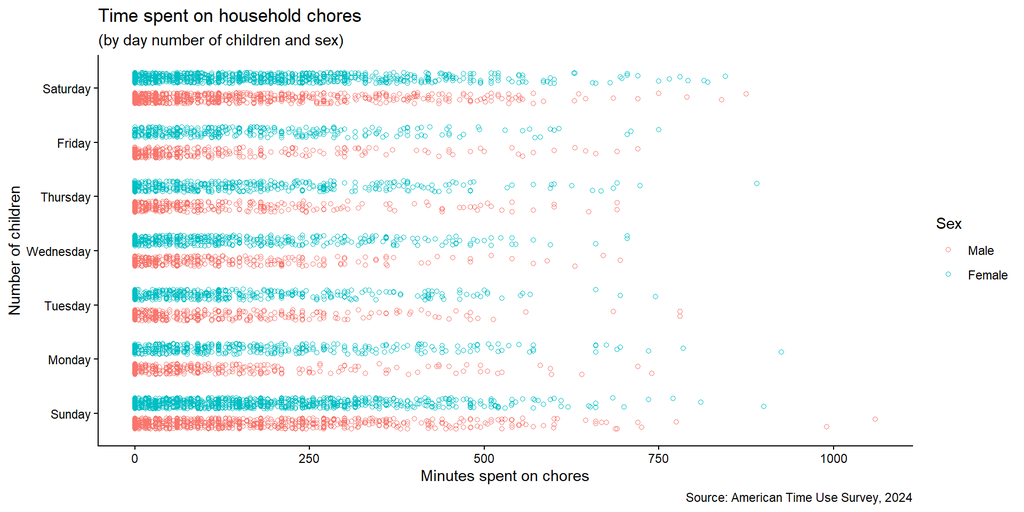

```r
ggplot(data  = atus_fmt, aes(y=TUDIARYDAY, color=TESEX, x = chores))  +
  geom_point(pch = 21, position = position_jitterdodge()) +
  labs(
    title = "Time spent on household chores",
    subtitle = "(by day number of children and sex)",
    x = "Minutes spent on chores",
    y = "Number of children",
    color = "Sex",
    caption = "Source: American Time Use Survey, 2024",
  ) +
  theme_classic()
```

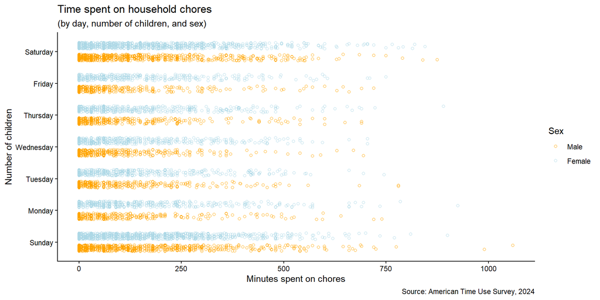

```r
ggplot(data  = atus_fmt, aes(y=TUDIARYDAY, color=TESEX, x = chores))  +
  geom_point(pch = 21, position = position_jitterdodge()) +
  labs(
    title = "Time spent on household chores",
    subtitle = "(by day, number of children, and sex)",
    x = "Minutes spent on chores",
    y = "Number of children",
    color = "Sex",
    caption = "Source: American Time Use Survey, 2024",
  ) +
  theme_classic() +
  scale_color_manual(values = c("orange", "lightblue"))
```

## Try it out

1. Use boxplots or jittered points to examine the relationship between `TESEX` (sex) and `hh_caretaking` (caring for household members)
2. Use color coding/fills to visualize this relationship by `GTMETSTA` (metropolitan status)
3. Try adding a custom color palette using `scale_fill_manual()` or `scale_color_manual()` (you’ll need to pick three color values)

### Aggregation

In a lot of cases, you’ll need to do some aggregation in order to get a meaningful visual summary of some relationship. The `stat_summary` functions can automatically aggregate by group:

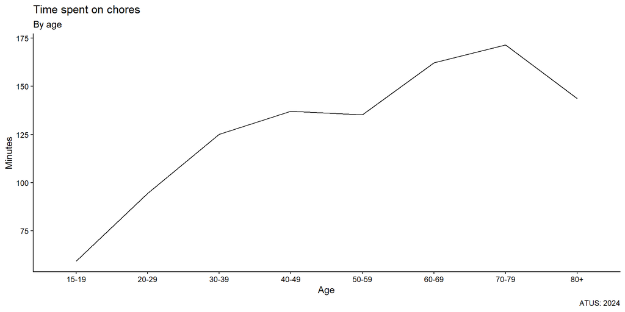

```r
ggplot(atus_fmt, aes(x=decade, y = chores, group=1)) +
  stat_summary(fun = mean, geom = "line", color = "black") +
  theme_bw() +
  labs(
    title = "Time spent on chores",
    subtitle = "By age",
    x = "Age",
    y = "Minutes",
    caption = "ATUS: 2024"
  )  +
  theme_classic()
```

### Aggregation

However, this is a little inflexible, so in many cases it makes sense to do the aggregation step separately.

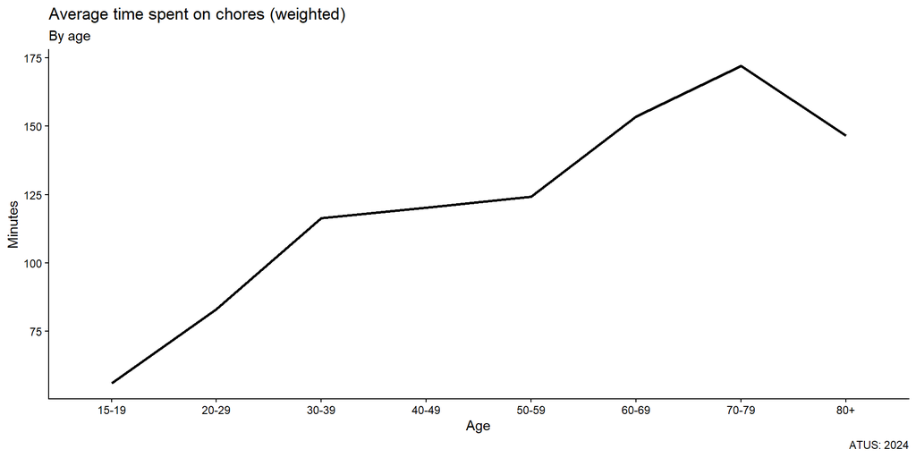

```r
atus_agg<-atus_fmt|>
  group_by(decade)|>
  summarise(
            wtd_chores = weighted.mean(x=chores,
                                       w =TUFINLWGT,
                                       na.rm=T)

            )

ggplot(atus_agg, aes(x=decade, y = wtd_chores, group=1)) +
  geom_line(lwd=1)+
  theme_bw() +
  labs(
    title = "Average time spent on chores (weighted)",
    subtitle = "By age",
    x = "Age",
    y = "Minutes",
    caption = "ATUS: 2024"
  ) +
  theme_classic()
```

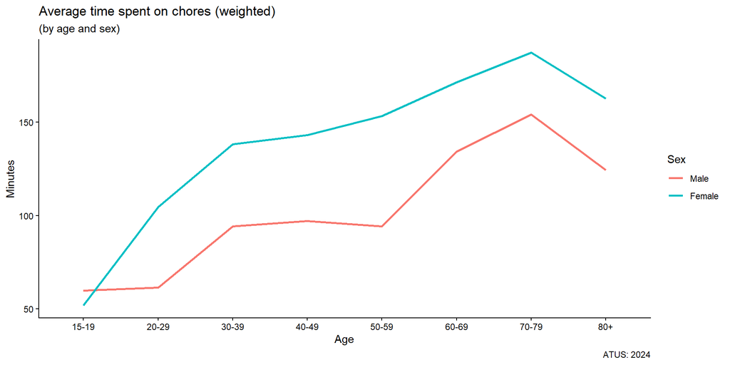

```r
atus_agg<-atus_fmt|>
  group_by(decade, TESEX)|>
  summarise(
            wtd_chores = weighted.mean(x=chores,
                                       w =TUFINLWGT,
                                       na.rm=T)
            )

ggplot(atus_agg, aes(x=decade, y = wtd_chores,
                     color=TESEX,
                     group=TESEX)) +
  geom_line(lwd=1)+
  theme_bw() +
  labs(
    title = "Average time spent on chores (weighted)",
    subtitle = "(by age and sex)",
    x = "Age",
    y = "Minutes",
    color= 'Sex',
    caption = "ATUS: 2024"
  ) +
  theme_classic()
```

### Faceting

Alternatively, faceting with `facet_wrap` or `facet_grid` splits your data into multiple subplots (panels) based on one or more categorical variables.

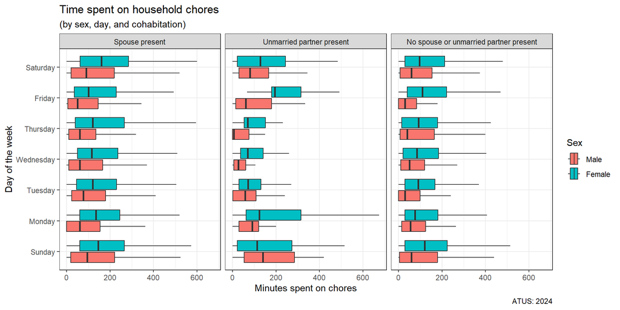

```r
ggplot(data  = atus_fmt, aes(x = chores,
                             y = TUDIARYDAY,
                             fill = TESEX,
                             shape =TESEX
                             ))  +

  geom_boxplot(outliers=FALSE) + # removing outliers
  labs(
     title = "Time spent on household chores",
    subtitle = "(by sex, day, and cohabitation)",
    x = "Minutes spent on chores",
    y = "Day of the week",
    caption = "ATUS: 2024",
    fill = "Sex", # Adjusting color legend title
    shape = "Sex" # Adjusting shape legend title
  ) +
  theme_bw() +
  facet_wrap(~TRSPPRES)
```

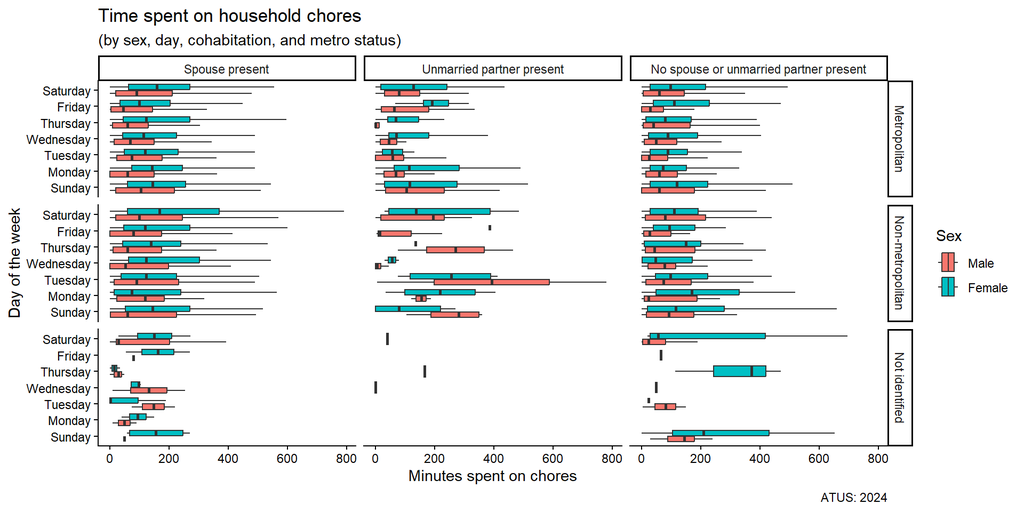

```r
ggplot(data  = atus_fmt, aes(x = chores,
                             y = TUDIARYDAY,
                             fill = TESEX))  +
  geom_boxplot(outliers=FALSE) +
  labs(
 title = "Time spent on household chores",
 subtitle = "(by sex, day, cohabitation, and metro status)",
    x = "Minutes spent on chores",
    y = "Day of the week",
    caption = "ATUS: 2024",
    fill = "Sex" # Adjusting the legend title
  ) +
  theme_classic() +
  # row var ~ column var
  facet_grid(GTMETSTA ~TRSPPRES)
```

## Try it out

- Make a faceted plot showing the relationship between time spent volunteering by day and sex.

### Long data

- ggplot works best with long format data. If we want to visualize several variables at once, you’ll often need to do some additional data wrangling.

### Long data

```r
# store the variable labels in a list
labels<-lapply(atus_fmt, function(x) attr(x, "label"))|>
  unlist()
# make long format data
time_long<-atus_fmt|>
  # selecting only the weight + columns related to activities
  select(sleep:travel, TUFINLWGT)|>
  # pivoting everything except the weights
  pivot_longer(cols=-TUFINLWGT)|>
  # adding the labels as a new column
  mutate(label = labels[name])

# viewing the results
time_long|>
  slice_head(n=10)
```

```
# A tibble: 10 × 4
   TUFINLWGT name          value label
       <dbl> <chr>         <dbl> <chr>
 1 18318135. sleep           540 Sleep
 2 18318135. self_care         0 Personal care
 3 18318135. chores           30 Household chores
 4 18318135. hh_caretaking   203 Caring for household members
 5 18318135. nonhh_care        0 Caring for non-hh members
 6 18318135. work            492 Work & work Related activities.
 7 18318135. education         0 Education
 8 18318135. shopping          0 Consumer purchases
 9 18318135. care_services     0 Professional & Personal Care Services
10 18318135. hh_services       0 Household services
```

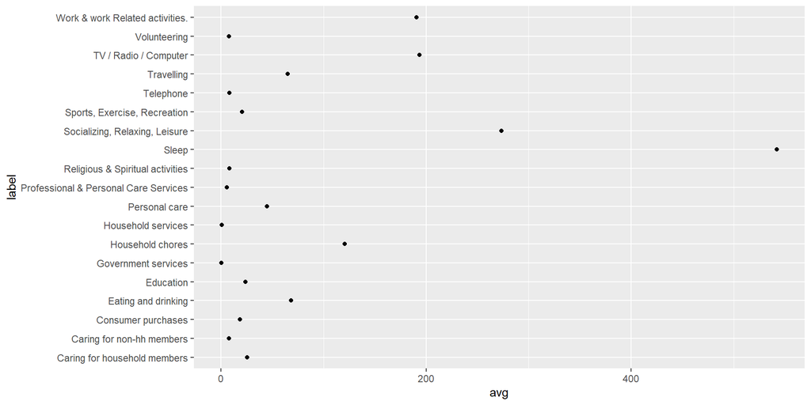

```r
time_aggregate<-time_long|>
  group_by(label)|>
  summarize(avg = weighted.mean(value, w=TUFINLWGT))
ggplot(time_aggregate, aes(x = avg, y=label)) + geom_point()
```

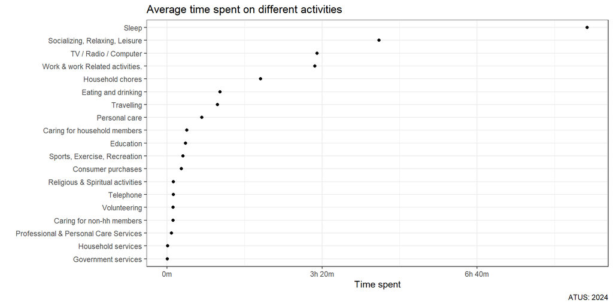

```r
time_aggregate<-time_long|>
  group_by(label)|>
  summarize(avg = weighted.mean(value, w=TUFINLWGT))|>
  mutate(label = reorder(label, avg))

ggplot(time_aggregate, aes(x = avg, y=label)) +
  geom_point() +
  labs(
 title = "Average time spent on different activities",
    x = "Time spent",
    y = "",
    caption = "ATUS: 2024"  ) +
  scale_x_continuous(labels = label_hours_minutes) +
  theme_bw()
```

### Faceting and scaling

Big differences in the scaling can make it difficult to identify *relative* changes within each group. Faceting with “free” axes can be a useful way to highlight a change at the expense of distorting absolute values.

### Faceting and scaling

This plot shows hours spent on different activities by age using the same scale for each facet.

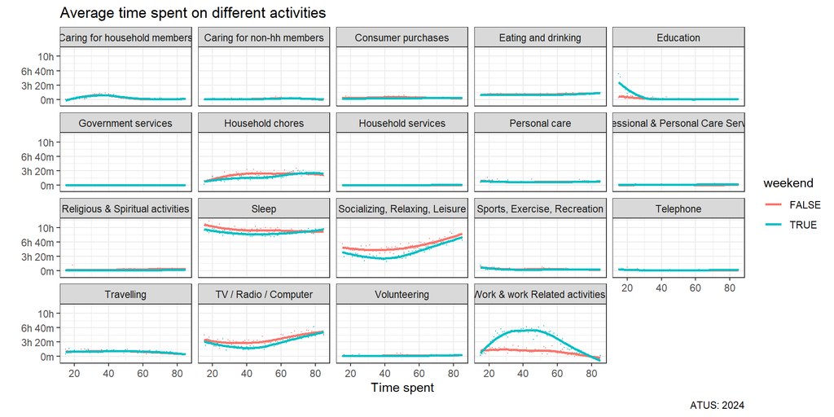

```r
time_long<-atus_fmt|>
  mutate(weekend = !TUDIARYDAY %in% c("Saturday", "Sunday"))|>
  select(sleep:travel, TEAGE, TUFINLWGT, weekend)|>
  pivot_longer(cols=-c(TUFINLWGT, weekend, TEAGE))|>
  mutate(label = labels[name])

time_aggregate<-time_long|>
  group_by(label, weekend, TEAGE)|>
  summarize(avg = weighted.mean(value, w=TUFINLWGT))


ggplot(time_aggregate, aes(x = TEAGE, y =avg,
                           color=weekend,
                           group=weekend)) +
  geom_point(size=.1) +
  geom_smooth(se=FALSE) +
  labs(
    title = "Average time spent on different activities",
    x = "Time spent",
    y = "",
    caption = "ATUS: 2024"  ) +
  scale_y_continuous(labels = label_hours_minutes) +
  theme_bw() +
  facet_wrap(~label)
```

Here’s what it looks like using a “free” y scale:

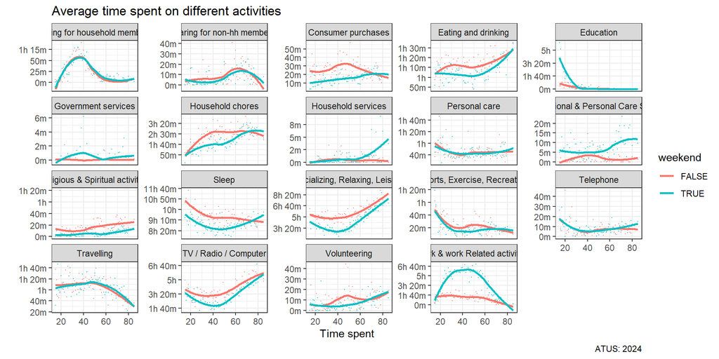

```r
time_long<-atus_fmt|>
  mutate(weekend = !TUDIARYDAY %in% c("Saturday", "Sunday"))|>
  select(sleep:travel, TEAGE, TUFINLWGT, weekend)|>
  pivot_longer(cols=-c(TUFINLWGT, weekend, TEAGE))|>
  mutate(label = labels[name])

time_aggregate<-time_long|>
  group_by(label, weekend, TEAGE)|>
  summarize(avg = weighted.mean(value, w=TUFINLWGT))


ggplot(time_aggregate, aes(x = TEAGE, y =avg,
                           color=weekend,
                           group=weekend)) +
  geom_point(size=.1) +
  geom_smooth(se=FALSE) +
  labs(
    title = "Average time spent on different activities",
    x = "Time spent",
    y = "",
    caption = "ATUS: 2024"  ) +
  scale_y_continuous(labels = label_hours_minutes) +
  theme_bw() +
  facet_wrap(~label,
             # Free scale on the y-axis
             scales='free_y')
```

## Try it out

- Variables beginning with `t130` are specific sports and recreation activities. Select all of these variables and put your results in long format (`t130101:t130301`)
- Get a break down of time spent in different activities by weekly income (`TRERNWA`)

## Try it out

- Does teleworking (`telework`) increase or decrease the sex disparity in time spent on household chores among full time workers (`TRDPFTPT== 'Full time'`)? Make a visual to support your argument.

## Survey data

Some special considerations for survey visualization:

- Visualizations for categorical data
- Visualizing weighted responses
- Handling over-plotting
- Visualizing the margin of error
- Visualizing the results from a model

### Survey data: Categorical Responses and Weights

- Many survey variables are categorical rather than continuous, which can restrict our options for visualization.

#### Survey data: Bar plots

`geom_bar` automatically creates bars proportional to the number of observations.

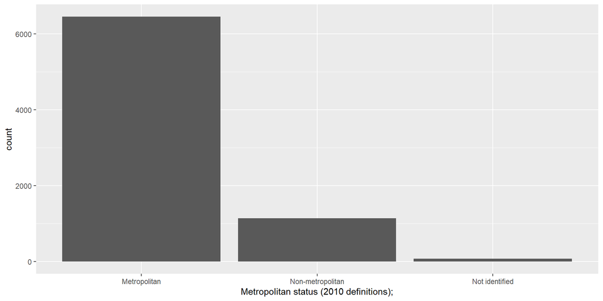

```r
ggplot(atus_fmt, aes(x=GTMETSTA)) +
  geom_bar()
```

`geom_col` creates bars that are proportional to a value in the data (so you need to create the aggregated data yourself)

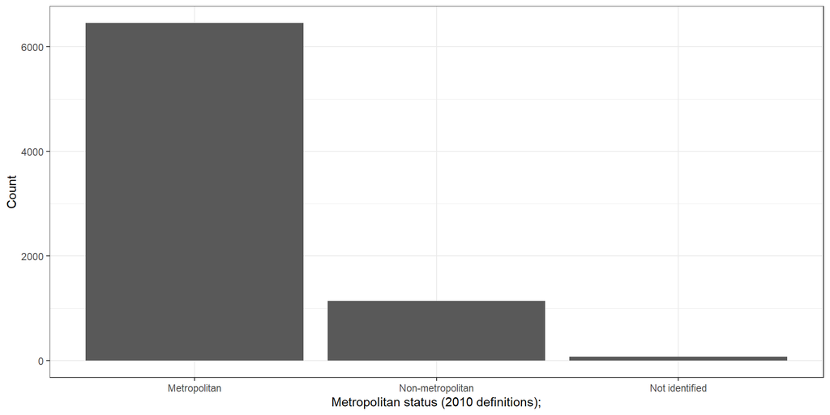

```r
atus_agg<-atus_fmt|>
  group_by(GTMETSTA)|>
  summarise(Count = n())

ggplot(atus_agg, aes(x=GTMETSTA, y= Count)) +
  geom_col() +
  theme_bw()
```

Doing the aggregation separately offers better flexibility for calculations and formatting.

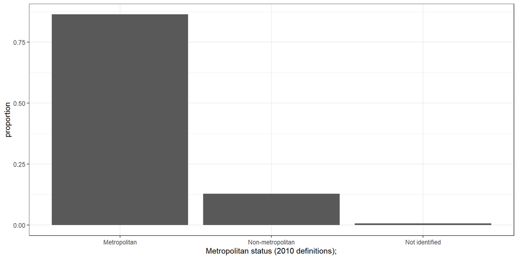

```r
atus_agg<-atus_fmt|>
  group_by(GTMETSTA)|>
  summarise(count = sum(TUFINLWGT))|>
  mutate(proportion = count /sum(count))

ggplot(atus_agg, aes(x=GTMETSTA, y=proportion)) +
  geom_col() +
  theme_bw()
```

Creating a dumbbell plot using `geom_pointrange` can be an appealing alternative to bar plots that focuses more attention on the important stuff (the ends)

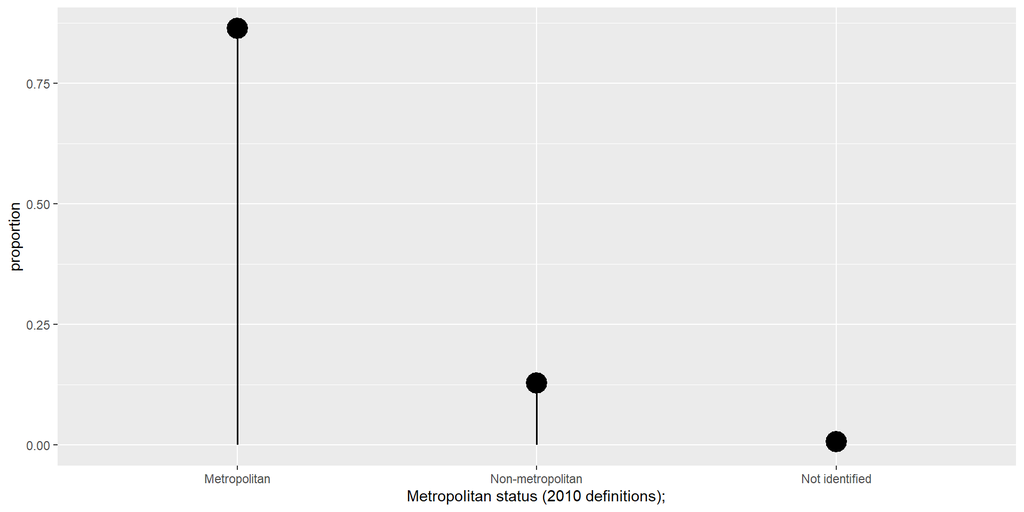

```r
atus_agg<-atus_fmt|>
  group_by(GTMETSTA)|>
  summarise(count = sum(TUFINLWGT))|>
  mutate(proportion = count /sum(count))

ggplot(atus_agg, aes(x=GTMETSTA, y=proportion)) +
    geom_pointrange(aes(ymin = 0, ymax = proportion),
                  # making wider lines
                  lwd=.7,
                  # increasing the point size
                  size = 1.5)
```